# Stat 437 HW4A

John Salmon (011745357)

# General rule

Please show your work and submit your computer codes in order to get points. Providing correct answers without supporting details does not receive full credits. This HW covers

- Discriminant analysis

For an assignment or project, you DO NOT have to submit your answers or reports using typesetting software. However, your answers must be well organized and well legible for grading. Please upload your answers in a document to the course space. Specifically, if you are not able to knit a .Rmd/.rmd file into an output file such as a .pdf, .doc, .docx or .html file that contains your codes, outputs from your codes, your interpretations on the outputs, and your answers in text (possibly with math expressions), please organize your codes, their outputs and your answers in a document in the format given below:

```
Problem or task or question ...
Codes ...
Outputs ...
Your interpretations ...
```

It is absolutely not OK to just submit your codes only. This will result in a considerable loss of points on your assignments or projects.

# Conceptual exercises: III (Discriminant analysis)

. Exercise 2 of Section 4.7 of the Text, which starts with “It was stated in the text that classifying an observation to the class for which (4.12) is largest is equivalent to classifying an observation to the class for which (4.13) is largest. Prove that this is the case.” (Helpful information on how to prove this is contained in the lecture video on LDA and “LectureNotes5b_notes.pdf”.)

Equation 4.12: $p+k(X) = \frac{\pi_k\frac{1}{\sqrt{2\pi\sigma}}exp(-\frac{1}{2\sigma^2}(x-\mu_k)^2)}{\sum^{K}_{l=1} \pi_l \frac{1}{2\pi\sigma}exp(-\frac{1}{2\sigma^2}(x-\mu_l)^2)}$

Start by taking the numerator of 4.12 because the class that maximizes $p_k(x)$ is the class that maximizes the numerator: $\pi_k * exp(-1\frac{1}{2\sigma^2}(x-\mu_k)^2)$

Next take the log to simplify the exponential function: $\pi_k * exp(-1\frac{1}{2\sigma^2}(x-\mu_k)^2) = log(\pi_k) - \frac{1}{2\sigma^2}(x-\mu_k)^2$

Expand the quadratic term: $(x - \mu_k)^2 = x^2 - 2x\mu_k + \mu^2_k$

Put together we have $log(\pi_k) - \frac{1}{2\sigma^2}(x^2 - 2x\mu_k + \mu^2_k) = log(\pi_k) - \frac{x^2}{2\sigma^2}+\frac{x\mu_k}{\sigma^2}-\frac{\mu^2_k}{2\sigma^2}$

The term $\frac{x^2}{2\sigma^2}$ does not depend on k so it is a constant term that can be dropped. Doing so leaves us with: $log(\pi_k) + \frac{x\mu_k}{\sigma^2}-\frac{\mu^2_k}{2\sigma^2}$ with some re-arrangement we get…:

Equation 4.13: $\delta_k(x) = x * \frac{\mu_k}{\sigma^2} - \frac{\mu^2_k}{2\sigma^2} + log(\pi_k)$

. Exercise 3 of Section 4.7 of the Text, which starts with “This problem relates to the QDA model, in which the observations within each class are drawn from a normal distribution with a class specific mean vector and a class specific covariance matrix. We consider the simple case where p = 1; i.e. there is only one feature.” (Helpful information on how to prove this is contained in the lecture video on QDA and “LectureNotes5b_notes.pdf”.)

The density of an observation from the kth class drawn from a 1D normal distribution is

$f_k(x) = \frac{1}{\sqrt{2\pi\sigma^2_k}}exp(-\frac{(x-\mu_k)^2}{2\sigma^2_k})$ each class has a prior probability of $\pi_k$

The Bayes classifier assigns x to the class that maximizes the product $\pi_kf_k(x) = \pi_k * \frac{1}{\sqrt{2\pi\sigma^2_k}}exp(-\frac{(x-\mu_k)^2}{2\sigma^2_k})$

taking the log to simplify the exp(): $log(\pi_kf_k(x)) = log(\pi_k)-\frac{1}{2}log(2\pi\sigma^2_k)-\frac{(x-\mu_k)^2}{2\sigma^2_k}$

$log(2\pi)$ is a constant so it can be dropped since it doesn’t on k: $log(pi_k) - \frac{1}{2}log(\sigma^2_k)-\frac{(x-\mu_k)^2}{2\sigma^2_k}$

expand the squared term: $(x-\mu_k)^2 = x^2 - 2x\mu_k + \mu^2_k$ so now its this: $log(\pi_k) - \frac{1}{2}log(\sigma^2_k) - \frac{1}{2\sigma^2_k}(x^2 - 2x\mu_k + \mu^2_k)$

distribute: $\delta_k(x) = log(\pi_k)-\frac{1}{2}log(\sigma^2_k)-\frac{x^2}{2\sigma^2_k}+\frac{x\mu_k}{\sigma^2_k}-\frac{\mu^2_k}{2\sigma^2_k}$

When comparing between two classes to decide which gives the higher discriminant score, the decision rules says we should pick the class that maximizes $\delta_k(x)$. The coefficient in front of the $x^2$ term changes for the different classes and the decision boundary equations is obtained by setting the discriminant functions for two classes equal to each other: $\delta_k(x)=\delta_l()x$

This gives a quadratic equation because of the differing $x^2$ coefficients making the decision surface quadratic. The discriminant functions involve quadratic terms, so the resulting bayes classifier under the QDA model is not linear. Hence the name Quadratic Discriminant Analysis.

. Exercise 5 of Section 4.7 of the Text, which starts with “We now examine the differences between LDA and QDA.” (Hint: for this question, you may also use information from Figures 4.9, 4.10 and 4.11 in the Text.)

-(a) If the Bayes decision boundary is linear we can expect that the QDA model may have slightly better (lower) training error because it has slightly more flexible model parameters that may allow it to overfit to the training set. However in the test set, with unseen data the LDA model should perform best because of the correct match of linear decision boundary and the lower variance because of its fewer parameters to estimate compared to QDA.

-(b) If the Bayes decision boundary is non-linear we can expect similar results. QDA will likely fit best on the training set performance because it estimates a separate matrix for each class allowing it to capture the non-linear decision boundary in the training set. In the test set LDA will have a higher bias but lower variance, because QDA is flexible it can capture the non-linear boundary but may have extra variance if the training set did not have many observations.

-(c)In general as the sample size increases the test prediction accuracy of QDA should improve compared to LDA. This is because QDA relies on estimation and more data allows for better estimates of predictions. Additionally, with smaller sample sizes QDA has to estimate more parameters which can lead to problems with over fitting.

. Let $Y$ be the random variable for the class label of a random vector $X \in \mathbb{R}^p$ (where $p$ is the number of features), such that $Y \in \mathcal{G}=\{1,\ldots, K\}$ and $\Pr(Y=k)=\pi_k$ for Class $k$ with $k \in \mathcal{G}$, where $K \ge 2$ is the number of classes. Consider the Gaussian mixture model such that the conditional density of $X$ when it comes from Class $k$ is $f_k(x) \sim \text{Gaussian}(\mu_k,\Sigma_k)$. Given the training set $\mathcal{T}$ of $n$ observations $(x_{1},y_{1}),\ldots,(x_{n},y_{n})$ on $(X,Y)$, where $y_i$ is the class label of observation $x_i$, do the following:

6.1) Provide the MLEs of $\pi_k$, $\mu_k$ and $\Sigma_k$ for each $k \in \mathcal{G}$ respectively for the case where all $\Sigma_k$’s are equal and for the case where not all $\Sigma_k$’s are equal. When $p >n$, is the MLE of $\Sigma_k$ still accurate? If not, recommend a different estimator for estimating $\Sigma_k$ and provide details on this estimator.

When all $\Sigma_k$’s are equal: - $\hat{\pi_k} = \frac{n_k}{n}$ - $\hat{\mu_k} = \frac{1}{n_k}\sum_{y_i=k}x_i$ - $\hat{\Sigma_k} = \frac{1}{n}\sum^K_{y_i=k}(x_i-\hat{\mu_k})(x_i-\hat{\mu_k})^T$

When all $\Sigma_k$’s different: - $\hat{\pi_k} = \frac{n_k}{n}$ - $\hat{\mu_k} = \frac{1}{n_k}\sum_{y_i=k}x_i$ - $\hat{\Sigma_k} = \frac{1}{n_k}\sum^K_{y_i=k}(x_i-\hat{\mu_k})(x_i-\hat{\mu_k})^T$

For cases when $p > n$ the MLE of $\Sigma_k$ will be unstable because the sample covariance matrix becomes singular and cannot be inverted. To address this I would suggest using RDA which uses $\lambda \text{and} \gamma$ to control the regularization of the co-variances in LDA and QDA.

6.2) Assume $p=2$ and $K=2$ and $k=1$. For the density $f_k(x) \sim \text{Gaussian}(\mu_k,\Sigma_k)$, what shape do its contours take, and how does $\Sigma_k$ control the shape of these contours? How do you check if the conditional density of $X$ given that it comes from Class $k$ is Gaussian?

The contours in this case will be ellipses and their shape size and orientation are determined by the covariance matrix. To if the conditional density of X given class k, we can use the visual methods that we went over during lecture, or I think there may be some statistical tests (Shapiro-Wilk?) that could tell you. Additionally tou can use MLE to estimate the parameters and look at how it fits.

6.3) Is it true that discriminant analysis will perform badly if the Gaussian assumption is violated? (Hint: for this question, you may also use the information provided by Figures 4.10 and 4.11 of the Text.) Let $X=(X_1,\ldots,X_p)^P$, i.e., $X_1$ up to $X_p$ are the feature variables. Can discriminant analysis be applied to observations of $X$ when some of $X_j,j=1\ldots,p$ is a discrete variable (such as a categorical variable)? Explain your answer.

When the Gaussian assumption is violated, there is not a guarantee that the discriminant model will perform poorly, however it is pretty likely that it will. The model will likely struggle to capture the true distribution of the data leading to incorrect classification boundaries. Especially the LDA model as it is more rigid in its assumption that the covariance matrices are the same across classes.

Discriminant Analysis cannot directly handle categorical features. The data it takes in needs to be continuous because the decision boundary is derived by calculating the likelihood of a data point belonging to a particular class. The categorical likelihood would be estimated by counting the frequency of each category so it doesn’t fit well with the Gaussian assumption.

6.4) What is a ROC curve, and what is AUC? How is AUC used to gauge the performance of a classifier? If you apply the same classifier, say, LDA or QDA under the same Gaussian mixture model, to two data sets that are independently generated from the same data generating process, i.e., that are independently generated from $(X,Y)$ for classification problems, and obtain two ROC curves, would the two ROC curves be quite different? Explain your answer. When there are 3 or more classes, are the codes provided in the lecture notes able to obtain ROC curves and their AUC’s for LDA and QDA?

The ROC curve shows the ability of a classification model to distinguish between classes at different thresholds. The two axis represent Sensitivity or true positive rate against the specificity or false positive rate. As the threshold level changes the balance between these two changes and is shown by the curve. AUC is the area under the curve which summarizes the overall performance of the classifier by providing a value between 0 and 1. 0.5 would be the typical value of a classifier that just randomly picks classes to assign to. 1 would be a perfect classifier and 0 would be a bad classifier.

If you were to create an ROC curve for two synthetically generated data sets from the same distribution, you would likely get 2 curves that are very similar but may or may not be identical. This is because both datasets may have some sampling variability which leads to differences in the points, and that the decision boundaries that are created by looking at the training data may be slightly different because of randomness in data sampling.

I suspect that the code provided in the lecture notes wouldn’t be sufficient to generate ROC curves for 3 or more classes. When there are more than 3 classes the thresholds become more complicated and I’m not sure how you would display that with a ROC curve.

6.5) Describe the key similarities and differences, respectively, between LDA and logistic regression. Provide a situation where discriminant analysis can still be sensibly applied but logistic regression is not well-defined.

Similarities: - LDA and Logistic Regression are both supervised learning techniques for classification tasks. - Both use a linear decision boundary. - Both methods model the probability of a data point belonging to a class

Differences: - LDA assumes the features are normally distributed, Logistic Regression does not care about the distribution of the data. - LDA estimates the class conditional probabilities and uses Bayes rule to compute the posterior probability, logistic regression models the probability of a class with the sigmoid logistic function.

A situation where LDA would work but logistic regression may not, is in a situation where the data set is high dimensional but the number of observations is low. This could be the case in research of a rare genetic disease where there are many gene expressions but not that many people have the disease with the “correct” gene expressions to study. In this case LDA can be applied because it just estimates the means and covariance matrices of the classes (has disease vs doesn’t have disease) even with a small sample set, it can still work. But the logistic regression model may struggle to estimate the coefficients for its logistic function. It won’t be able to find a stable solution because it will over fit and struggle with the multidisciplinary of the data.

# Applied exercises: III (Discriminant analysis)

. The following is on software commands:

(8.1) What is the main cause of the message “Warning in `lda.default`(x, grouping, …): variables are collinear”? What is the main cause of the message “Error in `qda.default`(x, grouping, …) : some group is too small for ‘qda’”?

- The variables are colinear message is shown when one or more variable in the data set form linear combinations of others, this results in a covariance matrix that in not invertible which the LDA calculation relies on to calculate the discriminant function. This introduces instability to the calculations where it becomes overly sensitive to small adjustments
- The too small for qda message means that the groups in the predicted (response) variable has too few observations. Because QDA relies on estimating separate covariance matrices for each group there need to be a sufficient number of observations relative to the number of predictors to generate accurate estimates. If the groups are too small the estimations can fail or become unstable possibly resulting in inaccuracy

(8.2) Provide details on the `list` that `predict{MASS}` returns.

- For the predict.lda() method, the return of the method is a list with three components: Class, posterior, and x. The class specifies the predicted class as a factor, posterior gives the posterior probabilities for the classes, and x gives the scores of the test cases.
- For predict.qda() the list only contains the posterior and class components which are the same as lda. The x component is omitted.

(8.3) The arguments `gamma` and `lambda` of `rda{klaR}` are usually determined by cross-validation. Can they be set manually?

- Both the lambda and gamma value can be manually set, using the regularization parameter. However, I’m not sure why you would do that because with out cross validation its not clear what the values to set them to should be.

. We will use the human cancer micro-array data that were discussed in the lectures and are provided by the R library `ElemStatLearn` (available at https://cran.r-project.org/src/contrib/Archive/ElemStatLearn/). Pick 3 cancer types “MELANOMA”, “OVARIAN” and “RENAL”, and randomly select the same set of $60$ genes for each cancer type. Please use `set.seed(123)` for the whole of this exercise. Your analysis will be based on observations for these genes and cancer types.

```
##
## MELANOMA  OVARIAN    RENAL
##        8        6        9
```

9.1) Pick 2 features and visualize the observations using the 2 features. Do you think it is hard to classify the observations based on the amount of overlap among the 3 neighborhoods of observations in each of the 3 classes? Here “a neighborhood of observations in a class” is a “open disk that contains the observations in the class”.

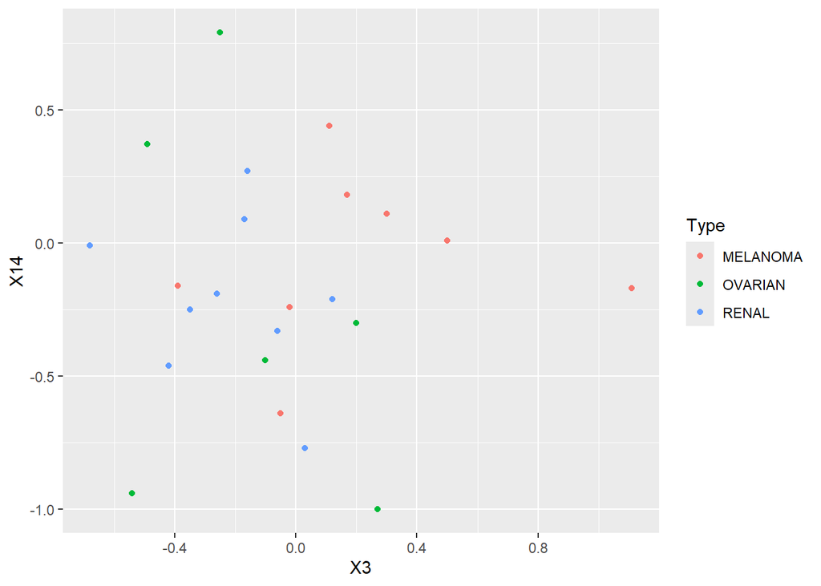

```r
library(ggplot2)
ggplot(data = cancer, aes(x = X3, y = X14, colour = Type)) +
    geom_point()
```

9.2) Apply LDA and report the class-wise error rate for each cancer type.

```r
library(MASS)
lda.fit = lda(Type ~ ., data = cancer)
lda.predictions = predict(lda.fit, cancer)
true_cancer_types = cancer$Type
predicted_cancer_type = lda.predictions$class

t = table(predicted_cancer_type, true_cancer_types)
print(t)
```

```
##                      true_cancer_types
## predicted_cancer_type MELANOMA OVARIAN RENAL
##              MELANOMA        6       0     0
##              OVARIAN         0       5     0
##              RENAL           2       1     9
```

```r
cat("Total Accuracy:", (sum(diag(t))/sum(t)) * 100, "%")
```

```
## Total Accuracy: 86.95652 %
```

9.3) Use the library `klaR`, and apply regularized discriminant analysis (RDA) by setting the arguments `gamma` and `lambda` of `rda{klaR}` manually so that the resulting class-wise error rate for each cancer type is zero.

```r
library(klaR)
rda.fit = rda(Type ~ ., data = cancer, gamma = 0.05, lambda = 0.23)
rda.pred = predict(rda.fit, cancer)
t = table(rda.pred$class, cancer$Type)
print(t)
```

```
##
##            MELANOMA OVARIAN RENAL
##   MELANOMA        8       0     0
##   OVARIAN         0       6     0
##   RENAL           0       0     9
```

```r
cat("Total Accuracy:", (sum(diag(t))/sum(t)) * 100, "%")
```

```
## Total Accuracy: 100 %
```

9.4) Obtain the estimated covariance matrices from the RDA and visualize them using the same strategy in Example 3 in “LectureNotes5c_notes.pdf”. What can you say about the degree of dependence among these genes for each of the three cancer types? (Hint and caution: the class labels “MELANOMA”, “OVARIAN” and “RENAL” will be ordered alphabetically by R. So, you need to keep track on which estimated covariance matrix is for which class. Otherwise, you will get wrong visualization.)

```r
library(reshape2)
```

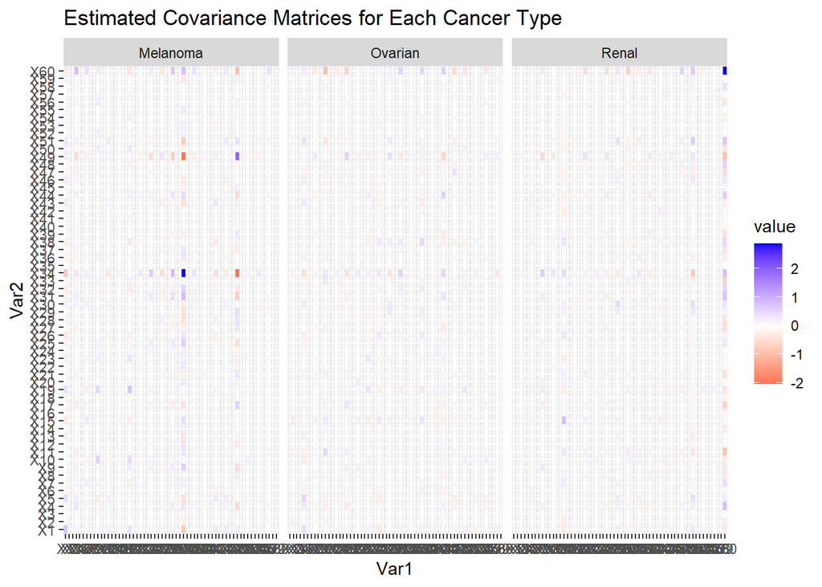

```r
hatSigma1 = rda.fit$covariances[, , 1]
hatSigma2 = rda.fit$covariances[, , 2]
hatSigma3 = rda.fit$covariances[, , 3]

m_hs1 = melt(hatSigma1)
m_hs2 = melt(hatSigma2)
m_hs3 = melt(hatSigma3)
All = rbind(m_hs1, m_hs2, m_hs3)
All$Cancer = rep(c("Melanoma", "Ovarian", "Renal"))
All$Cancer = factor(All$Cancer)

cov_plot = ggplot(data = All, aes(x = Var1, y = Var2, fill = value)) +
    geom_tile() + scale_fill_gradient2(low = "red", high = "blue") +
    facet_grid(~Cancer) + ggtitle("Estimated Covariance Matrices for Each Cancer Type")

cov_plot
```